# Multidimensional Analysis of Internacional Tourism (1995-2020)

Author

María Yu García Muñoz

Published

October 20, 2025

## Introduction

This project analyzes the **evolution of international tourism** between 1995 and 2020, using three complementary dimensions: **international tourist arrivals**, **international tourism expenditure**, and **short-stay accommodation capacity**. The aim is not only to understand how tourism demand has changed over time, but also to examine how these shifts are reflected in investment patterns and available infrastructure—enabling the identification of global trends and meaningful comparisons among the world’s leading tourism destinations.

## Block 1: International Tourist Arrivals

[figure not shown]

```r
# Leer XML desde archivo local

xml_file <- "C:\\Users\\ymari\\Downloads\\API_ST.INT.ARVL_DS2_en_xml_v2_21512\\API_ST.INT.ARVL_DS2_en_xml_v2_21512.xml"
xml <- read_xml(xml_file)

# Extraer registros

records <- xml_find_all(xml, "//record")

# Función para parsear cada registro a tibble

parse_record <- function(record) {
fields <- xml_find_all(record, ".//field")
tibble(
country = xml_text(fields[xml_attr(fields, "name") == "Country or Area"]),
country_code = xml_attr(fields[xml_attr(fields, "name") == "Country or Area"], "key"),
item = xml_text(fields[xml_attr(fields, "name") == "Item"]),
item_code = xml_attr(fields[xml_attr(fields, "name") == "Item"], "key"),
year = xml_text(fields[xml_attr(fields, "name") == "Year"]),
value = xml_text(fields[xml_attr(fields, "name") == "Value"])
)
}

df <- map_df(records, parse_record)

# Convertir a numéricos y limpiar

df <- df %>%
mutate(
year = as.integer(year),
value = as.numeric(value)
) %>%
filter(!is.na(value))

# Filtrar países válidos

df_paises <- df %>%
  filter(!grepl(
    "\\(|area|region|income|countries|Caribbean|Baltics|Euro|demographic|IBRD|IDA|World|Union|OECD|Fragile|conflict|small states|excl|total|group",
    country, ignore.case = TRUE))


# Selección top 10 países con mayor número de turistas

top10_countries <- df_paises %>%
group_by(country) %>%
summarise(total_tourists = sum(value, na.rm = TRUE)) %>%
arrange(desc(total_tourists)) %>%
slice(1:10) %>%
pull(country)

nombres_esp <- tibble(
country = c("China", "France", "Mexico", "East Asia & Pacific", "Italy",
"Middle East, North Africa, Afghanistan & Pakistan",
"North America", "Poland"),
country_es = c("China", "Francia", "México", "Asia Oriental y Pacífico",
"Italia", "Oriente Medio y Norte de África",
"Norteamérica", "Polonia")
)

df_plot <- df %>%
left_join(nombres_esp, by = "country") %>%
mutate(country_final = if_else(!is.na(country_es), country_es, country))

ggplot(df_plot %>% filter(country_final %in% nombres_esp$country_es),
aes(x = year, y = value, color = country_final, group = country_final)) +
geom_line(size = 1.2) +
geom_point(size = 3) +
scale_x_continuous(limits = c(1995, max(df$year, na.rm = TRUE))) +
scale_y_continuous(labels = comma_format(big.mark = ".", decimal.mark = ",")) +
labs(
title = "Evolución del turismo internacional en los 10 países con mayor número de turistas",
subtitle = "Datos del período 1995-2020",
x = "Año",
y = "Número de llegadas",
color = "País"
) +
theme_economist() +
theme(
  plot.title.position = "plot",
  plot.title = element_text(face = "bold", size = 16, hjust = 0.5, margin = margin(b = 10)),
  plot.subtitle = element_text(size = 14, hjust = 0.5, margin = margin(b = 15)),
  axis.title.x = element_text(margin = margin(t = 15)),
  axis.title.y = element_text(margin = margin(r = 15)),
  legend.position = "bottom"
)
```

Conversely, **2020 marked a historic collapse** in international tourism due to the **COVID-19 pandemic**. Travel restrictions, border closures, and social distancing measures led to a **70% global decline** in international tourist arrivals compared to 2019. This unprecedented drop severely disrupted both tourism demand and supply, resulting in a near-total halt of leisure and travel activities for much of the year. Persistent uncertainty and successive waves of infections further delayed any meaningful recovery of the sector.

# Block 2: International Tourism Expenditure

The analysis then turns to **international tourism expenditure**, data for which was retrieved via the **World Bank API**. This dimension goes beyond visitor volumes to examine **how much money tourists spend**, thereby adding an essential economic perspective to the assessment of tourism demand.

```r
# URL de la API
url_api <- "http://api.worldbank.org/v2/country/all/indicator/ST.INT.XPND.CD?format=json&date=1995:2020&per_page=20000"

# Petición GET
res <- httr::GET(url_api)
stop_for_status(res)
```

[output not shown]

```r
# Convertir a texto y luego JSON
txt <- content(res, as = "text", encoding = "UTF-8")
j <- fromJSON(txt, flatten = TRUE)
```

[output not shown]

```r
# Extraer el dataframe del JSON
df_gastos <- as_tibble(j[[2]]) %>%
  select(country = country.value, country_code = country.id, year = date, value) %>%
  mutate(year = as.integer(year),
         value = as.numeric(value)) %>%
  filter(!is.na(value))
```

[output not shown]

```r
# Filtrar países/regiones que no nos interesan
excluded_patterns <- "\\$$|area|region|income|countries|Caribbean|Baltics|Euro|demographic|IBRD|IDA|World|Union|OECD|Fragile|conflict|small states|excl|total|group"
df_gastos <- df_gastos %>%
  filter(!grepl(excluded_patterns, country, ignore.case = TRUE))
```

[output not shown]

```r
# Conversión a euros
tipo_cambio <- 0.93
df_gastos <- df_gastos %>%
  mutate(value_eur = value * tipo_cambio)
```

[output not shown]

```r
# Últimos 4 años
ultimo_anio <- max(df_gastos$year)
```

[output not shown]

```r
ultimos_anos <- (ultimo_anio-3):ultimo_anio
```

[output not shown]

```r
# Top 10 países por gasto
top10_gastos <- df_gastos %>%
  filter(year %in% ultimos_anos) %>%
  group_by(country) %>%
  summarise(total_gasto = sum(value_eur, na.rm = TRUE)) %>%
  arrange(desc(total_gasto)) %>%
  slice_head(n = 10) %>%
  pull(country)
```

[output not shown]

```r
df_top_gastos <- df_gastos %>%
  filter(country %in% top10_gastos, year %in% ultimos_anos)
```

[output not shown]

```r
nombres_esp_gasto <- tribble(
  ~country, ~pais,
  "Australia", "Australia",
  "France", "Francia",
  "Germany", "Alemania",
  "Italy", "Italia",
  "Korea, Rep.", "Corea del Sur",
  "Middle East, North Africa, Afghanistan & Pakistan", "Oriente Medio y N. África",
  "North America", "Norteamérica",
  "Russian Federation", "Rusia",
  "South Asia", "Asia del Sur",
  "United States", "Estados Unidos"
)

df_top_gastos_plot <- df_top_gastos %>%
  left_join(nombres_esp_gasto, by = "country") %>%
  mutate(pais = if_else(!is.na(pais), pais, country))
```

[output not shown]

```r
ggplot(df_top_gastos_plot, aes(x = factor(year), y = value_eur, fill = pais)) +
  geom_col(position = position_dodge(width = 0.8), width = 0.7) +
  scale_y_continuous(labels = comma_format(big.mark = ".", decimal.mark = ",")) +
  labs(
    title = "Gasto turístico internacional (€) - Top 10 países",
    subtitle = "Comparación por país y año",
    x = "Año", y = "Gasto turístico (millones EUR)", fill = "País"
  ) +
  theme_economist() +
theme(
  plot.title.position = "plot",
  plot.title = element_text(face = "bold", size = 16, hjust = 0.5, margin = margin(b = 10)),
  plot.subtitle = element_text(size = 14, hjust = 0.5, margin = margin(b = 15)),
  axis.title.x = element_text(margin = margin(t = 15)),
  axis.title.y = element_text(margin = margin(r = 15)),
  legend.position = "bottom"
)
```

[output not shown]

[output not shown]

# Block 3: Short-Stay Accommodation Capacity

Finally, **short-stay accommodation capacity** was analyzed using data sourced from **NationMaster**. The focus was placed on the **top 10 countries** by this indicator. Data extraction was performed via **Google Sheets**, using the `IMPORTHTML` function to directly pull structured data from the webpage, which was subsequently exported to **Excel (.xlsx)** format for further analysis.

This metric enables an assessment of how tourism **supply responds to demand**, offering insight into infrastructure preparedness and market maturity in leading destinations.

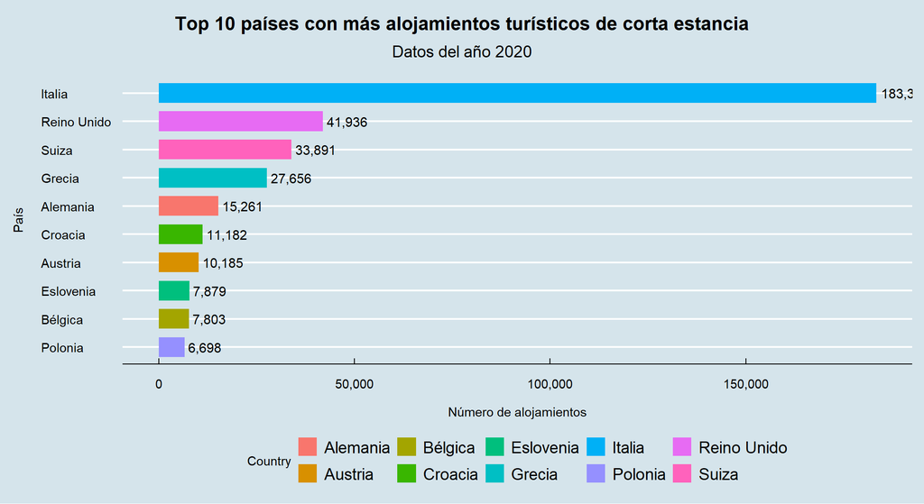

```r
# Ruta del archivo Excel descargado con los datos de alojamiento
ruta_xlsx <- "D:\\4 curso\\DNE\\DNE\\bloque_3.xlsx"

# Leer el archivo Excel y asignar tipos de columna (todo texto para limpiar más fácil)
df_gsheet <- read_excel(ruta_xlsx, col_types = c("text", "text", "text"))


colnames(df_gsheet) <- c("Country", "Units (Establishments)", "Year")

# Limpiar y transformar los datos principales
df_gsheet_limpio <- df_gsheet %>%
  # Quitar posibles prefijos numéricos y espacios extra en la columna país
  mutate(
    Country = str_trim(str_remove(Country, "^#\\d+\\s*")),
    # Convertir unidades de alojamiento a formato numérico, eliminando los puntos de miles
    `Units (Establishments)` = as.numeric(gsub("\\.", "", `Units (Establishments)`)),
    # Convertir año a numérico
    Year = as.numeric(Year)
  ) %>%
  select(Country, `Units (Establishments)`, Year)

# Traducir los nombres de país al español para facilitar la interpretación del gráfico y la tabla
df_gsheet_limpio <- df_gsheet_limpio %>%
  mutate(Country = recode(Country,
    "Italy" = "Italia",
    "Belgium" = "Bélgica",
    "Poland" = "Polonia",
    "Romania" = "Rumanía",
    "Portugal" = "Portugal",
    "France" = "Francia",
    "Greece" = "Grecia",
    "Spain" = "España",
    "Turkey" = "Turquía",
    "Germany" = "Alemania",
    "Croatia" = "Croacia",
    "Switzerland" = "Suiza",
    "Slovenia" = "Eslovenia",
    "United Kingdom" = "Reino Unido",
    .default = Country
  ))

# Seleccionar los 10 países con más alojamientos de corta estancia para visualización
df_gsheet_top10 <- df_gsheet_limpio %>%
  arrange(desc(`Units (Establishments)`)) %>%
  slice_head(n = 10)

ggplot(df_gsheet_top10, aes(x = reorder(Country, `Units (Establishments)`), y = `Units (Establishments)`, fill = Country)) +
  geom_col(width = 0.7) +
  coord_flip() +
  geom_text(aes(label = scales::comma(round(`Units (Establishments)`, 0))), hjust = -0.1, size = 4) +
  scale_y_continuous(labels = scales::comma) +
  labs(
    title = "Top 10 países con más alojamientos turísticos de corta estancia",
    subtitle = paste("Datos del año", max(df_gsheet_top10$Year)),
    x = "País",
    y = "Número de alojamientos"
  ) +
  theme_economist() +
theme(
  plot.title.position = "plot",
  plot.title = element_text(face = "bold", size = 16, hjust = 0.5, margin = margin(b = 10)),
  plot.subtitle = element_text(size = 14, hjust = 0.5, margin = margin(b = 15)),
  axis.title.x = element_text(margin = margin(t = 15)),
  axis.title.y = element_text(margin = margin(r = 15)),
  legend.position = "bottom"
)
```

An examination of the most recent data and the accompanying visualization reveals that **Italy, the United Kingdom, and Switzerland** clearly lead in terms of **short-stay tourism accommodation capacity**.

For instance, **Italy** not only tops the accommodation capacity ranking but has long remained one of the world’s most popular and economically successful tourism destinations. The country has effectively aligned its hotel and alternative lodging infrastructure with sustained and growing demand, reinforcing its competitiveness on the global stage.

By jointly analyzing **total visitor numbers**, **average tourist expenditure**, and **available tourism infrastructure**, a clearer picture emerges of why **Italy—and similar high-performing countries—maintain their leading position in international tourism**.

```r
DT::datatable(df_gsheet_limpio,
  options = list(pageLength = 15, autoWidth = TRUE),
  caption = 'Tabla completa de alojamientos turísticos'
)
```

|  | Country | Units (Establishments) | Year |
| --- | --- | --- | --- |
| 1 | Italia | 183316 | 2019 |
| 2 | Croacia | 11182 | 2019 |
| 3 | Reino Unido | 41936 | 2019 |
| 4 | Suiza | 33891 | 2018 |
| 5 | España | 3192 | 2019 |
| 6 | Grecia | 27656 | 2019 |
| 7 | Alemania | 15261 | 2019 |
| 8 | Austria | 10185 | 2020 |
| 9 | Eslovenia | 7879 | 2019 |
| 10 | Bélgica | 7803 | 2019 |

[output cut: 24 more lines]

# Conclusion

An integrated analysis of the three dimensions—**tourist arrivals**, **international tourism expenditure**, and **short-stay accommodation capacity**—reveals several key insights into the evolution of global tourism between 1995 and 2020.

First, the countries with the highest volume of international arrivals do not always align with those generating the highest tourism revenue. For instance, **China** attracts a very large number of visitors but with relatively moderate per-capita spending, whereas destinations like the **United States** or **South Korea** receive fewer tourists but benefit from significantly higher expenditure per visitor. This highlights the existence of **distinct tourism models**: volume-driven versus high-value strategies.

The global tourism landscape also reflects a strategic **diversification**: some nations prioritize scale, while others focus on economic yield per tourist. **Western Europe**, in particular, excels across all three indicators—high visitor flows, substantial expenditure, and extensive lodging infrastructure—solidifying its position as the world’s leading tourism region.

External factors—such as economic downturns, public health crises (notably the **2020 pandemic**), tourism policies, and geopolitical events—have demonstrated a **synchronous impact** on arrivals, spending, and investment in tourism infrastructure.

Ultimately, the synergy between **robust accommodation supply**, **steady tourist inflows**, and **high per-capita spending** illustrates a critical success factor: destinations that invest in diverse, high-quality infrastructure not only attract visitors but also foster loyalty and positive word-of-mouth.

In summary, examining arrivals, expenditure, and supply together provides a **comprehensive understanding** of tourism dynamics. The combination of adequate infrastructure, consistent demand, and high-value tourism is essential for a country to remain competitive and sustain long-term growth as a global destination.

# References

1. Moncanig. (2025). *Tema 2: Análisis del turismo internacional*. Retrieved from https://moncanig.quarto.pub/dne2526/Tema2.html
2. Organización Mundial del Turismo (OMT). (2019). *Informe sobre el turismo mundial 2019*. Retrieved from https://www.e-unwto.org/doi/pdf/10.18111/9789284413515
3. Travel Weekly. (2025, 19 de octubre). *The pot gets bigger: Vegas draws record 38.9M people*. Retrieved from https://www.travelweekly.com/North-America-Travel/The-pot-gets-bigger-Vegas-draws-record-38-9M-people
4. The Moodie Davitt Report. (2006, 29 de junio). *International tourism up 4.5% in January to April 2006, says World Tourism Organization*. Retrieved from https://moodiedavittreport.com/international-tourism-up-4-5-in-january-to-april-2006-says-world-tourism-organization-290606/
5. Organización Mundial del Turismo (OMT). (2025). *Estadísticas de turismo y alojamiento*. Retrieved from https://www.untourism.int/tourism-statistics/tourism-data-tourism-accommodation
6. National IT Industry Promotion Agency (NIPA). (2025). *Estadísticas de alojamiento turístico en Corea del Sur*. Retrieved from https://nia.or.kr/site/nia_kor/ex/bbs/View.do?cbIdx=99835&bcIdx=28652&parentSeq=28652
7. Banco Mundial. (2025). *Gasto en turismo internacional (ST.INT.XPND.CD)*. Retrieved from https://data.worldbank.org/indicator/ST.INT.XPND.CD?end=2020&locations=Z4&name_desc=false&start=1995&view=chart&year=1995
8. NationMaster. (2025). *Ranking de número de establecimientos de alojamiento de corta estancia*. Retrieved from https://www.nationmaster.com/nmx/ranking/number-of-short-stay-accommodations-establishments
9. Naciones Unidas. (2025). *Estadísticas de turismo internacional*. Retrieved from https://data.un.org/DocumentData.aspx?id=482